# Permafrost Grown

Researchers and farmers working together to understand permafrost-agriculture interactions

Permafrost Grown works with farmers in Alaska to understand how permafrost and agricultural activities interact. The goal is to develop management strategies and best-practice guides for farmers cultivating on permafrost-affected soils. In **year three of five**, the team has collected a wide range of data on the physical, social, economic and policy impacts of permafrost on northern farms.

This dashboard presents the Year 3 highlights with the underlying data made explorable - pan, zoom, switch layers and search the records yourself.

Thaw subsidence measured by drone, 2017-2023

up to 1.5 m

Bethel borehole records synthesised

762

Boreholes that reached permafrost

576

Project year, of five

3

Where the Year 3 work happened

[interactive chart not shown]

What is on this dashboard

**Using drones to monitor thaw subsidence** - 3D digital surface models let the team track how much the land has lowered as ground ice melts. Up to **1.5 m (about 5 feet)** of thaw subsidence occurred between 2017 and 2023 at a site first cleared for agriculture and cultivated until it was abandoned and converted into a golf course. Permafrost can keep degrading, with active thaw subsidence, long after cultivation stops.

**Discovery of ice wedges in the Bethel area** - near-surface permafrost information was synthesised from archived geotechnical reports, together with boreholes the team drilled in 2023 and 2024. That drilling found **wedge ice**, a type of massive ground ice not previously described in the Yukon-Kuskokwim Delta.

**Engaging farmers** - interviews, on-farm engagement, annual surveys, focus groups and workshops bring farmers and researchers together to generate new knowledge about permafrost-agroecosystems.

**Using drones to monitor thaw subsidence - Midnight Sun Golf Course, Fairbanks.** A 65 ha parcel cleared for agriculture, cultivated until it was abandoned, and converted to a golf course about 25 years ago. Ice-rich permafrost thaw following the original clearing contributed to that change in land use.

2023 drone lidar - ground surface and thaw features

[interactive chart not shown]

Source: Midnight Sun Golf Course classified lidar point cloud, digital surface model, digital terrain model and orthophoto mosaic, 10 September 2023 ([doi:10.18739/A2W37KX40](https://doi.org/10.18739/A2W37KX40)). Shaded relief and the “low ground” layer are derived here from the published 2023 digital terrain model; blue tones mark ground sitting below the local average surface - the pits, troughs and collapsed hollows that thawing ground ice leaves behind. The 2017-2023 change map in the printed Year 3 highlights uses an earlier borough lidar survey that is not part of this dataset and is not reproduced here.

Ground surface across a thaw hollow

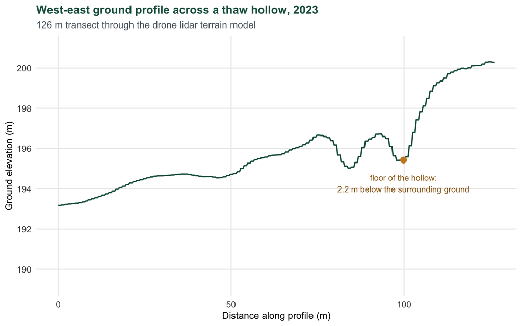

What this means on the ground

The 2023 drone survey covers **75 ha** at 25 cm resolution. About **11%** of that ground sits more than 0.5 m below its local average surface, and the most pronounced hollow on the site is **2.2 m (7 ft)** deep relative to the ground around it.

**Discovery of ice wedges in the Bethel area.** Bethel sits in a zone of discontinuous permafrost and was thought to lack ice wedges. To investigate the agricultural potential of the area, the team synthesised near-surface permafrost information from archived geotechnical reports, alongside boreholes drilled in 2023 and 2024. That drilling found wedge ice - a type of massive ground ice not previously described in the Yukon-Kuskokwim Delta.

Borehole records in the geospatial database

762

Permafrost reported

576 (76%)

Visible ground ice reported

183 (24%)

Median depth to frozen ground

2.6 m

Near-surface permafrost from Bethel geotechnical boreholes

[interactive chart not shown]

Source: Synthesis of near-surface permafrost borehole information from Bethel geotechnical reports ([doi:10.18739/A2P55DJ80](https://doi.org/10.18739/A2P55DJ80)). Tick one indicator at a time in the layer box; click any borehole for its full record.

What the borehole logs record

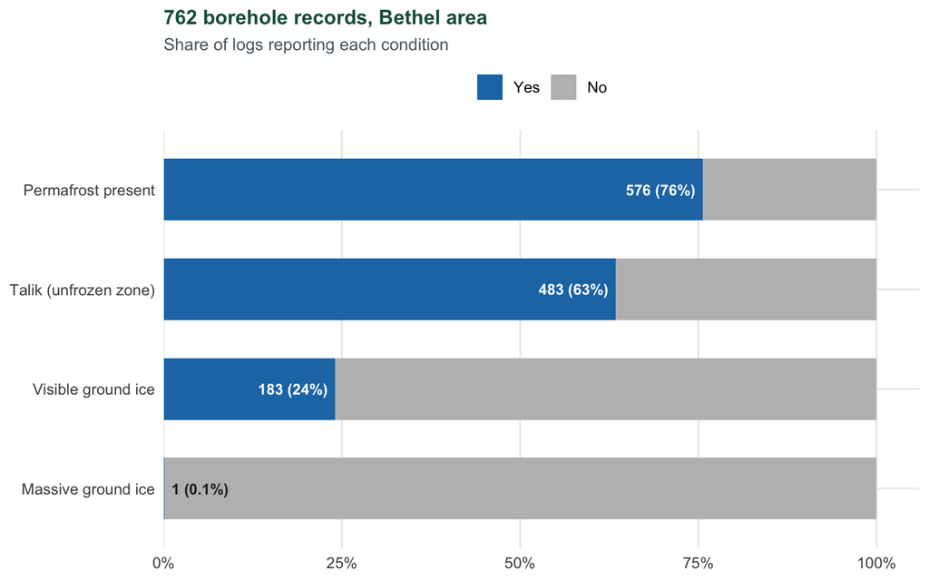

Depth to frozen ground

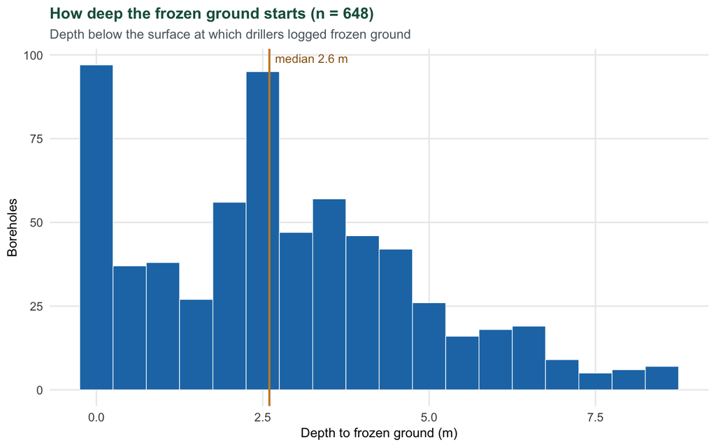

**Why ice wedges matter** - wedge ice is a body of nearly pure ice in the ground. When it thaws, the surface above it collapses into troughs and ponds rather than settling evenly. Knowing where it occurs changes where you would site a building pad, a road, a utility run or a field.

All Bethel borehole records - search, sort and download

| Site ID | Borehole | Agency | Report | Report year | Drilled | Depth (m) | Depth to frozen ground (m) | Base of frozen ground not reached | Permafrost | Talik | Visible ice | Massive ice | Latitude | Longitude |
| --- | --- | --- | --- | --- | --- | --- | --- | --- | --- | --- | --- | --- | --- | --- |
| 1992-DOT-TH1 | TH 92-1 | DOT&amp;PR | GEOTECHNICAL REPORT RIDGECREST DRIVE - BETHEL | 1996 | 1992-11-24 | 4.6 | 2.1 | yes | Yes | Yes | Yes | No | 60.79392 | -161.76912 |
| 1992-DOT-TH2 | TH 92-2 | DOT&amp;PR | GEOTECHNICAL REPORT RIDGECREST DRIVE - BETHEL | 1996 | 1992-11-24 | 4.6 | 1.8 | yes | Yes | Yes | No | No | 60.79471 | -161.77057 |
| 1992-DOT-TH3 | TH 92-3 | DOT&amp;PR | GEOTECHNICAL REPORT RIDGECREST DRIVE - BETHEL | 1996 | 1992-11-24 | 4.6 | 2.7 | yes | Yes | Yes | No | No | 60.7957 | -161.77232 |
| 1992-DOT-TH4 | TH 92-4 | DOT&amp;PR | GEOTECHNICAL REPORT RIDGECREST DRIVE - BETHEL | 1996 | 1992-11-24 | 4.6 | 4.3 | yes | Yes | Yes | No | No | 60.7964 | -161.77401 |
| 1992-DOT-TH5 | TH 92-5 | DOT&amp;PR | GEOTECHNICAL REPORT RIDGECREST DRIVE - BETHEL | 1996 | 1992-11-24 | 6.1 | 5.3 | yes | Yes | Yes | No | No | 60.79659 | -161.77431 |
| 1992-DOT-TH6 | TH 92-6 | DOT&amp;PR | GEOTECHNICAL REPORT RIDGECREST DRIVE - BETHEL | 1996 | 1992-11-24 | 5.2 | 4.6 | yes | Yes | Yes | No | No | 60.79737 | -161.77579 |
| 1992-DOT-TH7 | TH 92-7 | DOT&amp;PR | GEOTECHNICAL REPORT RIDGECREST DRIVE - BETHEL | 1996 | 1992-11-24 | 7.6 |  |  | No | Yes | No | No | 60.79833 | -161.77644 |
| 1992-DOT-TH8 | TH 92-8 | DOT&amp;PR | GEOTECHNICAL REPORT RIDGECREST DRIVE - BETHEL | 1996 | 1992-11-24 | 2.4 |  |  | No | No | No | No | 60.7984 | -161.77659 |
| 1992-DOT-TH9 | TH 92-9 | DOT&amp;PR | GEOTECHNICAL REPORT RIDGECREST DRIVE - BETHEL | 1996 | 1992-11-24 | 4.6 | 3.7 | yes | Yes | Yes | No | No | 60.79948 | -161.77674 |
| 1992-DOT-TH10 | TH 92-10 | DOT&amp;PR | GEOTECHNICAL REPORT RIDGECREST DRIVE - BETHEL | 1996 | 1992-11-24 | 3.7 | 2.3 | yes | Yes | Yes | No | No | 60.80076 | -161.77681 |

[output cut: 752 more lines]

“Base of frozen ground not reached” marks logs where the driller was still in frozen ground at the bottom of the hole, so the permafrost is at least as thick as the hole is deep. Blank depth cells are records where the original report gave no value.

Engaging farmers to understand impacts

The research team has collaborated with farmers to understand their experiences of farming within a permafrost-agroecosystem (PAE) through:

- interviews
- on-farm engagement
- annual surveys
- focus groups
- workshops

Together, farmers and researchers generate new knowledge and identify knowledge gaps through activities like a **Permafrost Degradation Game** and a **Land-purchasing Scenario Exercise**. These activities have highlighted increasing awareness of the need to understand the complex nature of a permafrost-agroecosystem’s biophysical properties for informed farm management.

The collaboration explores the social and ecological dimensions of agricultural management, providing guidance for mitigation, adaptive strategies and policy recommendations.

Putting it to work

**Before you clear land** - ice content below the surface, not the vegetation on top, decides how the ground will behave afterwards. A few boreholes or a ground-penetrating radar line is far cheaper than regrading a settled field.

**After clearing** - settling continues for years. Plan drainage for a surface that will keep changing shape, and re-survey periodically rather than once.

**For local government** - the same measurements that help a farm plan a field help a borough plan a road alignment, a gravel pad or a utility corridor. Both datasets behind this dashboard are openly licensed and can be loaded straight into GIS software.

Recent Permafrost Grown project publications

1. Ward Jones, M., et al. (2024). Socio-ecological dynamics of diverse global permafrost-agroecosystems under environmental change. *Arctic, Antarctic, and Alpine Research*, 56(1).
2. Parlato, N., and Ward Jones, M. (2025). The Law of Thaw: Understanding Subnational Land Use Policies for Permafrost-Agroecosystems. *Polar Record*, 61 (e3): 1-15.
3. Jones, B. et al. (In Review). Cryptic ice wedge networks in Holocene peat, Yukon-Kuskokwim Delta, Alaska. *Permafrost and Periglacial Processes*.

Permafrost Grown is funded by the National Science Foundation under RISE Award 2126965 - www.permafrostgrown.org

Where the data comes from

**Midnight Sun Golf Course drone lidar, Fairbanks.** Midnight Sun Golf Course Classified LiDAR Point Cloud, Digital Surface Model, Digital Terrain Model, Digital Photos, and Orthophoto Mosaic, 10 September 2023. Arctic Data Center, [doi:10.18739/A2W37KX40](https://doi.org/10.18739/A2W37KX40). Acquired with a DJI M300 drone carrying a Zenmuse L1 sensor flown in RTK mode at 60 m above ground level; the point cloud was classified into ground and non-ground returns and gridded to 25 cm digital surface and terrain models in WGS84 UTM Zone 6N, ellipsoid heights.

**Bethel borehole synthesis, Yukon-Kuskokwim Delta.** Synthesis of near-surface permafrost borehole information from Bethel geotechnical reports. Arctic Data Center, [doi:10.18739/A2P55DJ80](https://doi.org/10.18739/A2P55DJ80). Historical geotechnical drilling reports were scanned, made searchable with OCR, and the borehole records - depth to permafrost, permafrost presence, visible ice, massive ice and borehole depth - extracted by hand into a spatial table.

How the layers on this dashboard were made

| Layer | How it was derived |
| --- | --- |
| Shaded relief (2023) | Hillshade of the published 25 cm terrain model, averaged to a 1 m grid (sun 35 degrees altitude, 315 degrees azimuth). |
| Low ground / thaw features | Terrain model minus its own 61 m moving average. Negative values are ground lying below the local average surface. |
| Ground elevation | Published 25 cm terrain model averaged to a 1 m grid; ellipsoid heights in metres. |
| Borehole points | Published borehole table, plotted at its recorded latitude and longitude. |
| Depth to frozen ground | Field Frozen_Ground_Depth_Top, with the value 999 treated as missing per the dataset’s metadata. |

The printed Year 3 highlights show a 2017-2023 elevation-difference map built by differencing borough lidar flown in 2017 against the 2023 drone survey. The 2017 survey is not part of the published dataset, so this dashboard shows the 2023 surface and its thaw features directly rather than recomputing the change map. The 1.5 m figure quoted throughout is the project’s own published result.

Record counts: the borehole table holds 762 records naming 17 distinct reports, with report years 1975-2005 and drilling dates 1974-2004. The archived dataset also includes the scanned source reports. Massive ice is flagged in 1 of these historical records; the wedge ice described in the Year 3 highlights was found in the team’s own 2023-2024 drilling, which is reported separately.